# Lab 08 - Text Mining/NLP

# Learning goals

- Use `unnest_tokens()` and `unnest_ngrams()` to extract tokens and ngrams from text
- Use dplyr and ggplot2 to analyze and visualize text data
- Try a theme model using `topicmodels`

# Lab description

For this lab we will be working with the medical record transcriptions from https://www.mtsamples.com/. And is loaded and “fairly” cleaned at https://github.com/JSC370/JSC370-2024/tree/main/data/medical_transcriptions.

This markdown document should be rendered using `github_document` document.

### Setup packages

You should load in `dplyr`, (or `data.table` if you want to work that way), `ggplot2` and `tidytext`. Install `wordcloud`, `tm`, and `topicmodels` if you don’t alreadyh have them.

### Read in the Medical Transcriptions

Loading in reference transcription samples from https://www.mtsamples.com/

```r
library(tidytext)
library(tidyverse)
library(wordcloud)
library(tm)
library(topicmodels)
library(kableExtra)

mt_samples <- read_csv("https://raw.githubusercontent.com/JSC370/JSC370-2024/main/data/medical_transcriptions/mtsamples.csv")
mt_samples <- mt_samples |>
  select(description, medical_specialty, transcription)

head(mt_samples)
```

```
## # A tibble: 6 × 3
##   description                                    medical_specialty transcription
##   <chr>                                          <chr>             <chr>
## 1 A 23-year-old white female presents with comp… Allergy / Immuno… "SUBJECTIVE:…
## 2 Consult for laparoscopic gastric bypass.       Bariatrics        "PAST MEDICA…
## 3 Consult for laparoscopic gastric bypass.       Bariatrics        "HISTORY OF …
## 4 2-D M-Mode. Doppler.                           Cardiovascular /… "2-D M-MODE:…
## 5 2-D Echocardiogram                             Cardiovascular /… "1.  The lef…
## 6 Morbid obesity.  Laparoscopic antecolic anteg… Bariatrics        "PREOPERATIV…
```

## Question 1: What specialties do we have?

We can use `count()` from `dplyr` to figure out how many different medical specialties are in the data. Are these categories related? overlapping? evenly distributed? Make a bar plot.

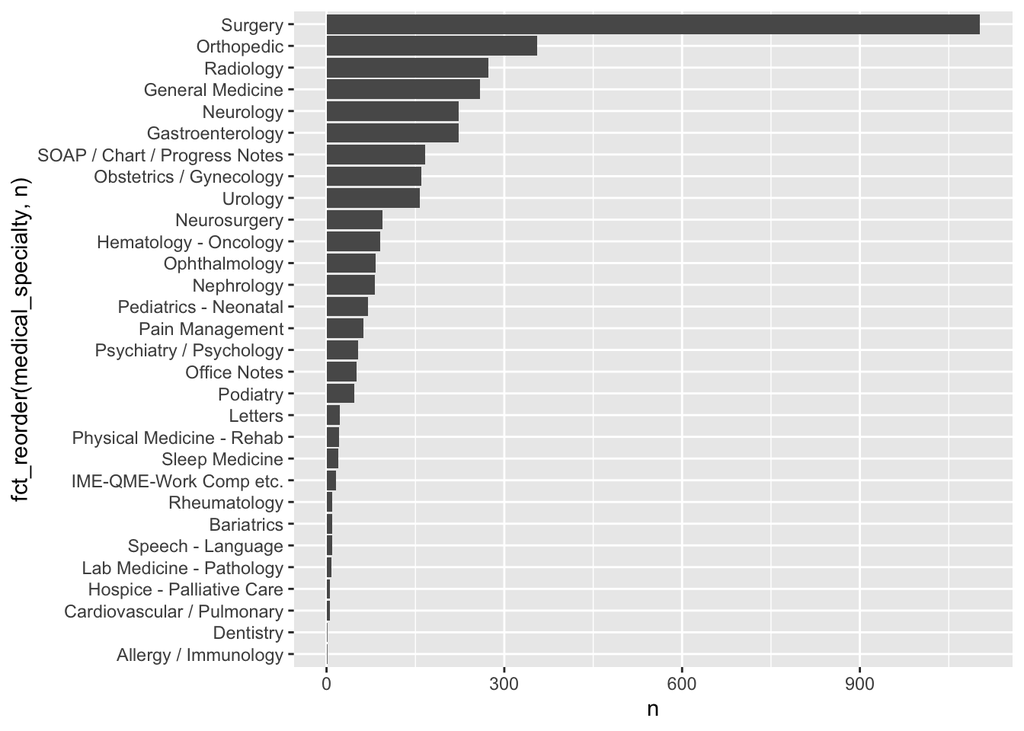

```r
mt_samples |>
  count(medical_specialty, sort = TRUE) |>
  ggplot(aes(fct_reorder(medical_specialty, n), n)) +
  geom_col() +
  coord_flip()
```

## Question 2: Tokenize

- Tokenize the the words in the `transcription` column
- Count the number of times each token appears
- Visualize the top 20 most frequent words with a bar plot
- Create a word cloud

Explain what we see from this result. Does it makes sense? What insights (if any) do we get?

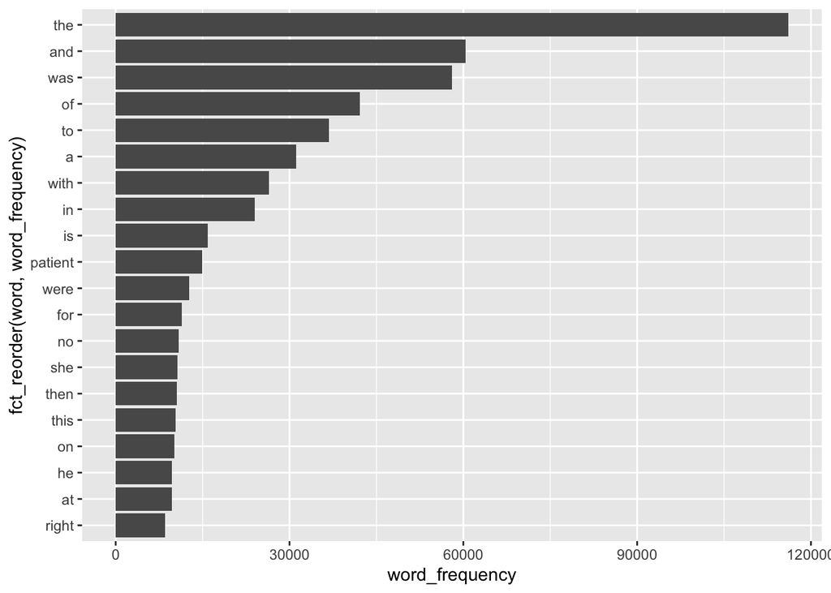

```r
tokens <- mt_samples |>
  select(transcription) |>
  unnest_tokens(word, transcription) |>
  group_by(word) |>
  summarize(word_frequency = n()) |>
  arrange(desc(word_frequency)) |>
  head(20)

tokens |>
  ggplot(aes(fct_reorder(word, word_frequency), word_frequency)) +
  geom_bar(stat = "identity") +
  coord_flip()
```

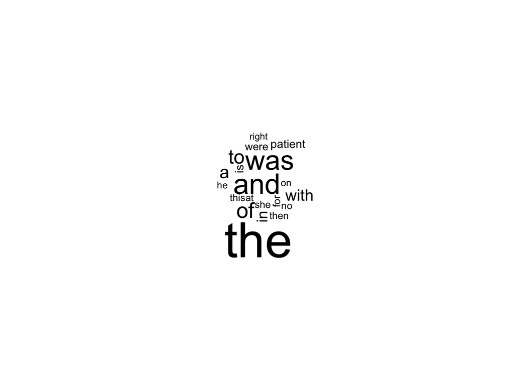

```r
wordcloud(words = tokens$word, freq = tokens$word_frequency)
```

## Question 3: Stopwords

- Redo Question 2 but remove stopwords(use stopwords package)
- Bonus points if you remove numbers as well (use regex)

What do we see know that we have removed stop words? Does it give us a better idea of what the text is about?

- Try customizing your stopwords list to include 3-4 additional words that do not appear informative

```r
head(stopwords("english"))
```

```
## [1] "i"      "me"     "my"     "myself" "we"     "our"
```

```r
length(stopwords("english"))
```

```
## [1] 174
```

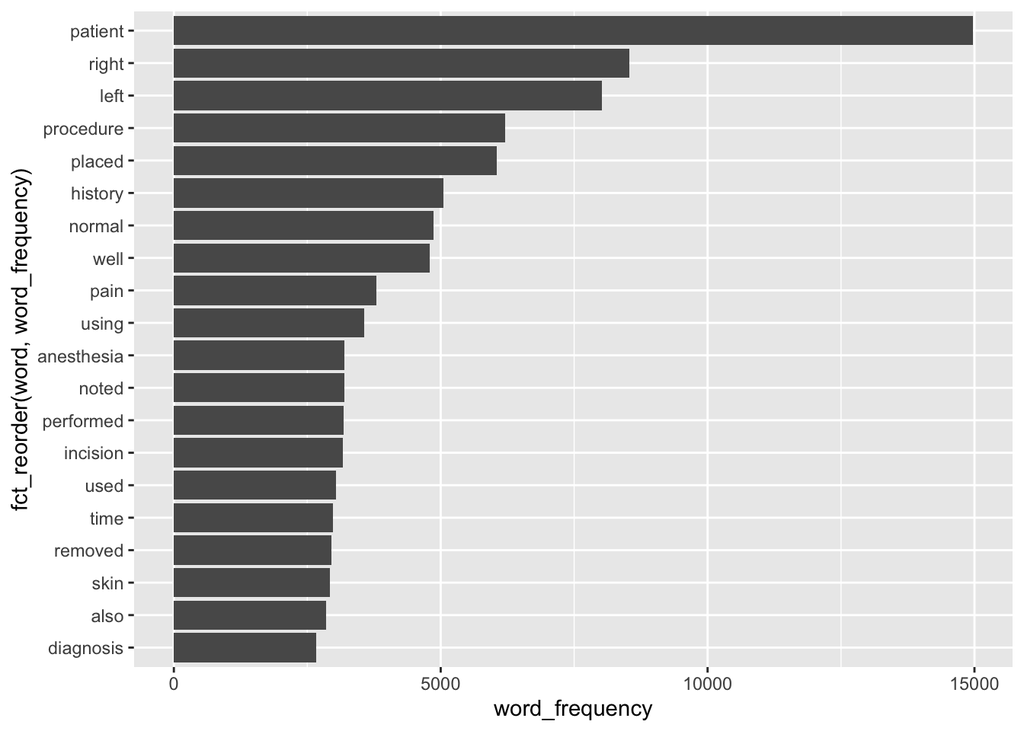

```r
tokens <- mt_samples |>
  select(transcription) |>
  unnest_tokens(word, transcription) |>
  filter(!(word %in% stopwords("english"))) |>
  filter(!grepl("[[:digit:]]+", word)) |>
  group_by(word) |>
  summarize(word_frequency = n()) |>
  arrange(desc(word_frequency)) |>
  head(20)

tokens |>
  ggplot(aes(fct_reorder(word, word_frequency), word_frequency)) +
  geom_bar(stat = "identity") +
  coord_flip()
```

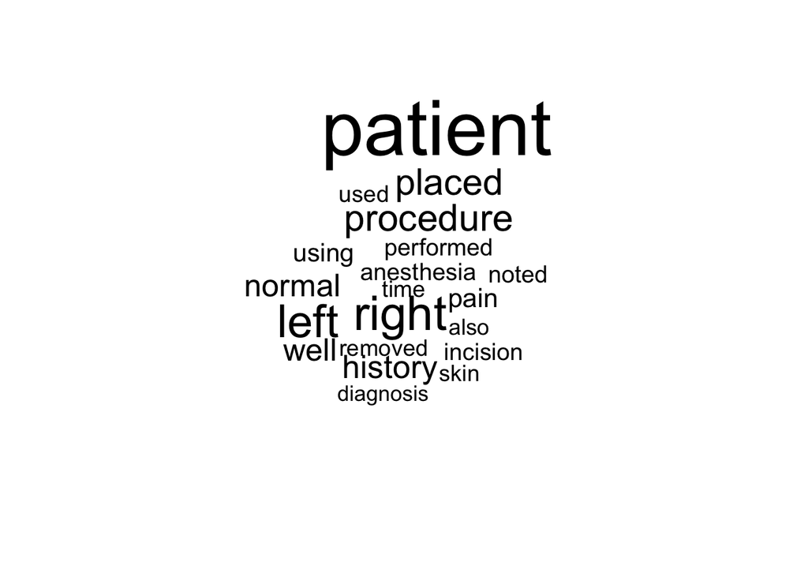

```r
wordcloud(words = tokens$word, freq = tokens$word_frequency)
```

```r
stopwords2 <- c(stopwords("english"), "also", "using", "use", "used")
```

# Question 4: ngrams

Repeat question 2, but this time tokenize into bi-grams. How does the result change if you look at tri-grams? Note we need to remove stopwords a little differently. You don’t need to recreate the wordclouds.

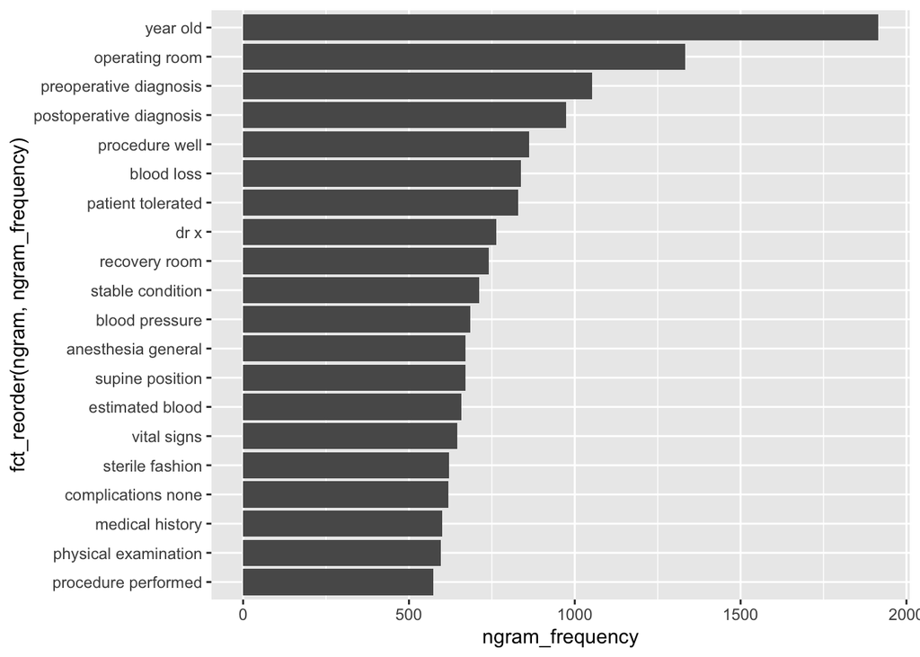

```r
sw_start <- paste0("^", paste(stopwords2, collapse = " |^"), "$")
sw_end <- paste0("", paste(stopwords2, collapse = "$| "), "$")

tokens_bigram <- mt_samples |>
  select(transcription) |>
  unnest_tokens(ngram, transcription, token = "ngrams", n = 2) |>
  filter(!grepl(sw_start, ngram, ignore.case = TRUE)) |>
  filter(!grepl(sw_end, ngram, ignore.case = TRUE)) |>
  filter(!grepl("[[:digit:]]+", ngram)) |>
  group_by(ngram) |>
  summarize(ngram_frequency = n()) |>
  arrange(desc(ngram_frequency))

tokens_bigram |>
  head(20) |>
  ggplot(aes(fct_reorder(ngram, ngram_frequency), ngram_frequency)) +
  geom_bar(stat = "identity") +
  coord_flip()
```

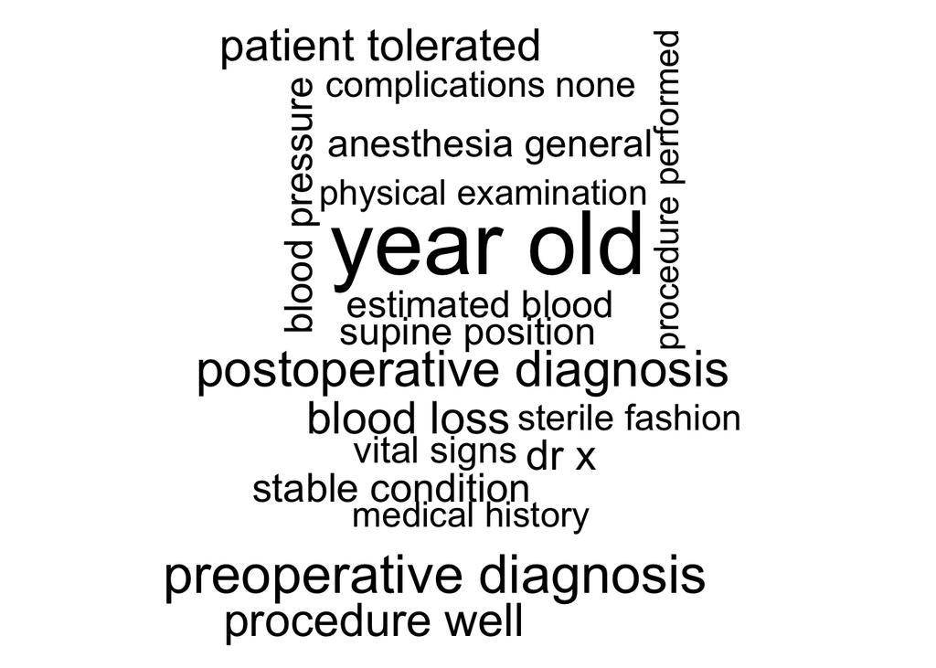

```r
wordcloud(
  words = head(tokens_bigram, 20)$ngram,
  freq = head(tokens_bigram, 20)$ngram_frequency
)
```

# Question 5: Examining words

Using the results from the bigram, pick a word and count the words that appear before and after it, and create a plot of the top 20.

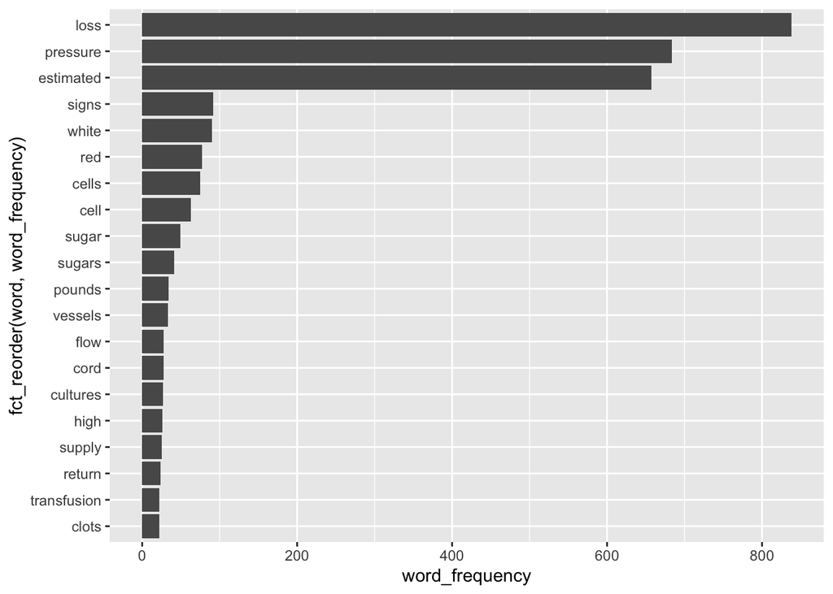

```r
library(stringr)
# e.g. patient, blood, preoperative...

tokens_bigram |>
  filter(str_detect(ngram, regex(" blood$|^blood "))) |>
  mutate(
    word = str_remove(ngram, "blood"),
    word = str_remove_all(word, " ")
  ) |>
  group_by(word) |>
  summarize(word_frequency = sum(ngram_frequency)) |>
  arrange(desc(word_frequency)) |>
  head(20) |>
  ggplot(aes(fct_reorder(word, word_frequency), word_frequency)) +
  geom_bar(stat = "identity") +
  coord_flip()
```

# Question 6: Words by Specialties

Which words are most used in each of the specialties. you can use `group_by()` and `top_n()` from `dplyr` to have the calculations be done within each specialty. Remember to remove stopwords. How about the most 5 used words?

```r
mt_samples |>
  unnest_tokens(word, transcription) |>
  filter(!(word %in% stopwords2)) |>
  filter(!grepl("[[:digit:]]+", word)) |>
  group_by(medical_specialty, word) |>
  summarize(word_frequency = n()) |>
  top_n(1) |>
  kbl() |>
  kable_styling() |>
  scroll_box(height = "500px")
```

| medical_specialty | word | word_frequency |
| --- | --- | --- |
| Allergy / Immunology | allergies | 4 |
| Bariatrics | patient | 29 |
| Cardiovascular / Pulmonary | normal | 25 |
| Dentistry | removed | 10 |
| Gastroenterology | patient | 835 |
| General Medicine | patient | 1356 |
| Hematology - Oncology | patient | 316 |
| Hospice - Palliative Care | patient | 43 |
| IME-QME-Work Comp etc. | pain | 152 |
| Lab Medicine - Pathology | cm | 35 |
| Lab Medicine - Pathology | tumor | 35 |
| Letters | pain | 80 |
| Nephrology | patient | 348 |
| Neurology | right | 694 |
| Neurosurgery | patient | 374 |
| Obstetrics / Gynecology | patient | 628 |
| Office Notes | normal | 230 |
| Ophthalmology | eye | 456 |
| Orthopedic | patient | 1711 |
| Pain Management | patient | 236 |
| Pediatrics - Neonatal | patient | 247 |
| Physical Medicine - Rehab | patient | 220 |
| Podiatry | foot | 232 |
| Psychiatry / Psychology | patient | 532 |
| Radiology | left | 701 |
| Rheumatology | history | 50 |
| SOAP / Chart / Progress Notes | patient | 537 |
| Sleep Medicine | sleep | 143 |
| Speech - Language | patient | 105 |
| Surgery | patient | 4855 |
| Urology | patient | 776 |

```r
mt_samples |>
  unnest_tokens(word, transcription) |>
  filter(!(word %in% stopwords2)) |>
  filter(!grepl("[[:digit:]]+", word)) |>
  group_by(medical_specialty, word) |>
  summarize(word_frequency = n()) |>
  top_n(5) |>
  kbl() |>
  kable_styling() |>
  scroll_box(height = "500px")
```

| medical_specialty | word | word_frequency |
| --- | --- | --- |
| Allergy / Immunology | allegra | 3 |
| Allergy / Immunology | allergies | 4 |
| Allergy / Immunology | clear | 3 |
| Allergy / Immunology | prescription | 3 |
| Allergy / Immunology | sprays | 3 |
| Bariatrics | abdomen | 20 |
| Bariatrics | history | 21 |
| Bariatrics | patient | 29 |
| Bariatrics | placed | 21 |
| Bariatrics | procedure | 18 |
| Cardiovascular / Pulmonary | aortic | 12 |
| Cardiovascular / Pulmonary | left | 18 |
| Cardiovascular / Pulmonary | normal | 25 |
| Cardiovascular / Pulmonary | trachea | 17 |
| Cardiovascular / Pulmonary | valve | 15 |
| Dentistry | area | 4 |
| Dentistry | aspect | 4 |
| Dentistry | blade | 4 |
| Dentistry | bone | 4 |
| Dentistry | buccal | 4 |
| Dentistry | bur | 4 |
| Dentistry | closed | 4 |
| Dentistry | elevator | 8 |
| Dentistry | envelope | 4 |
| Dentistry | flap | 4 |
| Dentistry | follicle | 4 |
| Dentistry | gut | 4 |
| Dentistry | incision | 4 |
| Dentistry | irrigated | 4 |
| Dentistry | made | 4 |

[output cut: 140 more lines]

# Question 7: Topic Models

See if there are any themes in the data by using a topic model (LDA).

- you first need to create a document term matrix
- then you can try the LDA function in `topicmodels`. Try different k values.
- create a facet plot of the results from the LDA (see code from lecture)

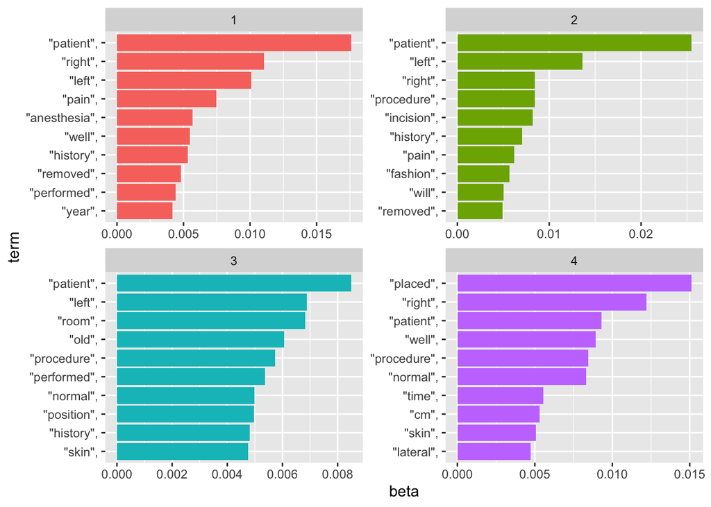

```r
transcripts_dtm <- mt_samples |>
  select(transcription) |>
  unnest_tokens(word, transcription) |>
  filter(!(word %in% stopwords2)) |>
  filter(!grepl("[[:digit:]]+", word)) |>
  DocumentTermMatrix()


transcripts_dtm <- as.matrix(transcripts_dtm)

transcripts_lda <- LDA(transcripts_dtm, k = 4, control = list(seed = 370))

tidy(transcripts_lda, matrix = "beta") |>
  group_by(topic) |>
  slice_max(beta, n = 10) |>
  ungroup() |>
  arrange(topic, -beta) |>
  mutate(term = reorder_within(term, beta, topic)) |>
  ggplot(aes(beta, term, fill = factor(topic))) +
  geom_col(show.legend = FALSE) +
  facet_wrap(~ topic, scales = "free") +
  scale_y_reordered()
```

# Deliverables

1. Questions 1-7 answered, raw .Rmd file and pdf or html output uploaded to Quercus